# Bootstrap Project

Arturo Prieto Tirado, César Antonio Conejo Villalobos

18/3/2021

Goal: Build a linear regression model to predict `y` in terms of some of the three variables `x1`,`x2` and `x3`.

0. The dataset contains outliers and after building any OLS model it can be checked that the error residuals are not normally distributed.

```r
model.lm <- lm(y ~  x1 + x2 + x3, data = datax)
summary(model.lm)$coef
```

```
##              Estimate Std. Error   t value   Pr(>|t|)
## (Intercept) 6.2945625   3.115619 2.0203247 0.04613578
## x1          0.9063926   3.300839 0.2745946 0.78421775
## x2          2.0242335   3.300098 0.6133859 0.54107178
## x3          3.9853100   3.298246 1.2083120 0.22989528
```

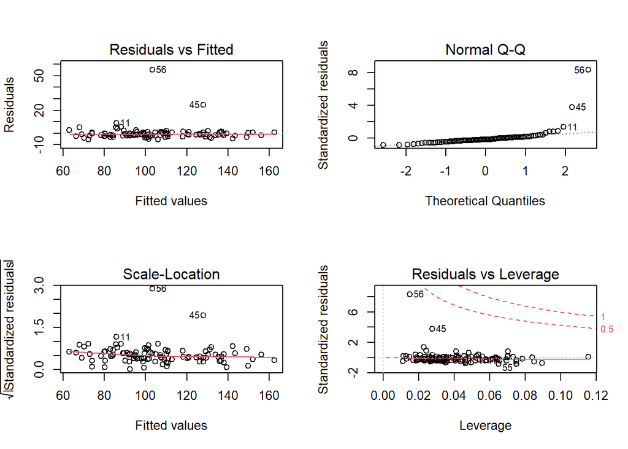

```r
#Diagnostics plots
par(mfrow=c(2,2))
plot(model.lm)
```

```r
rm(model.lm)
```

1. Build a robust linear regression model with the three covariates and use (95%) bootstrap confidence intervals on the regressors’ coefficients to study their significance.

```r
# Arturo: Bootstrap pairs

#first estimation from the data

fit=rlm(y~. ,data=datax)
est_coeff=fit$coefficients

#function to obtain coefficients from a linear regression model
rrpair<-function(x,xdata){
  rlm(y~.,data=xdata[x,],maxit=100)$coefficients
}
#get a sample of bootstrapped coefficients using the first 100 rows of the bootstrap generated dataset and doing this B times
set.seed(1)
B= 100   #1000
rbet<-bootstrap(x=1:100,nboot=B,theta=rrpair,xdata=datax)$thetastar

# Basic bootstrap interval (1-alpha so exchange limits)
2*est_coeff[1]-quantile(rbet[1,],c(0.975,0.025))
```

```
##    97.5%     2.5%
## 2.238106 6.756092
```

```r
2*est_coeff[2]-quantile(rbet[2,],c(0.975,0.025))
```

```
##    97.5%     2.5%
## 1.575668 5.658913
```

```r
2*est_coeff[3]-quantile(rbet[3,],c(0.975,0.025))
```

```
##    97.5%     2.5%
## 2.497574 6.655712
```

```r
2*est_coeff[4]-quantile(rbet[4,],c(0.975,0.025))
```

```
##      97.5%       2.5%
## -0.6803713  3.4495874
```

```r
# Cesar: Bootstrapping residuals (I think this is better in the case of outliers)

#function to generate coefficients in the residual sense
#instead of just sampling with replacement from our original sample to get new x,y
#now we sample from the residuals of the original model (rres) and define our new
#bootstrap sample as y_fit=ygorro+epsilon with epsilon="x" in this case
#and now fit a model on this new y
res_rob_rg <- function(x,beta,xdata){
  y_fit  <- beta[1] + beta[2]*xdata$x1 + beta[3]*xdata$x2 + beta[4]*xdata$x3 + x
  bmodel <- rlm(y_fit ~ x1 + x2 + x3, data = xdata)
  return(coef(bmodel))
}

rres    <- fit$residuals
rbeta.h <- coef(fit)

B <- 100
set.seed(1)
coeff.res <- bootstrap(rres, B, res_rob_rg, beta = rbeta.h, xdata = datax)$thetastar


# Basic Bootstrap

2*rbeta.h[1] - quantile(coeff.res[1,], c(0.975,0.025))
```

```
##    97.5%     2.5%
## 3.216581 6.613396
```

```r
2*rbeta.h[2] - quantile(coeff.res[2,], c(0.975,0.025))
```

```
##    97.5%     2.5%
## 2.194947 5.169157
```

```r
2*rbeta.h[3] - quantile(coeff.res[3,], c(0.975,0.025))
```

```
##    97.5%     2.5%
## 3.106893 6.128414
```

```r
2*rbeta.h[4] - quantile(coeff.res[4,], c(0.975,0.025))
```

```
##      97.5%       2.5%
## -0.2130038  2.8721808
```

```r
#  BCa (Does not work)
# bcanon(rres, B, res_rob_rg, beta = rbeta.h, xdata = data)
```

2. Use backward elimination to select the relevant covariates and provide the chosen regression model.